# Reproducible Research

*Course project 1*

**Loading and preprocessing the data** 1. Loading and preprocessing the data

```r
data<-read.csv("C:/Users/Anant Sharma/Desktop/DATA SCIENCE/Reproducible Research/Course project 1/activity.csv")
```

2. Processing the data:

```r
dim(data)
```

```
## [1] 17568     3
```

```r
names(data)
```

```
## [1] "steps"    "date"     "interval"
```

```r
str(data)
```

```
## 'data.frame':  17568 obs. of  3 variables:
##  $ steps   : int  NA NA NA NA NA NA NA NA NA NA ...
##  $ date    : Factor w/ 61 levels "2012-10-01","2012-10-02",..: 1 1 1 1 1 1 1 1 1 1 ...
##  $ interval: int  0 5 10 15 20 25 30 35 40 45 ...
```

**What is mean total number of steps taken per day?**

1. Total number of steps taken per day:

```r
q1<-data.frame(total.steps=tapply(data$steps,data$date,sum,na.rm=TRUE))
q1$date<-rownames(q1)
rownames(q1)<-NULL
q1
```

```
##    total.steps       date
## 1            0 2012-10-01
## 2          126 2012-10-02
## 3        11352 2012-10-03
## 4        12116 2012-10-04
## 5        13294 2012-10-05
## 6        15420 2012-10-06
## 7        11015 2012-10-07
## 8            0 2012-10-08
## 9        12811 2012-10-09
## 10        9900 2012-10-10
## 11       10304 2012-10-11
## 12       17382 2012-10-12
## 13       12426 2012-10-13
## 14       15098 2012-10-14
```

[output cut: 47 more lines]

2. Histogram of the total number of steps taken each day:

```r
q2<-data.frame(sum=tapply(data$steps,data$date,sum,na.rm=TRUE))
q2$date<-rownames(q2)
rownames(q2)<-NULL
library(ggplot2)
g<-ggplot(q2,aes(x=date,y=sum))
png(file="plot1.png")
g+geom_bar(stat="identity")+xlab("date")+ylab("Total steps")+ggtitle("Total steps on every day")
dev.off()
```

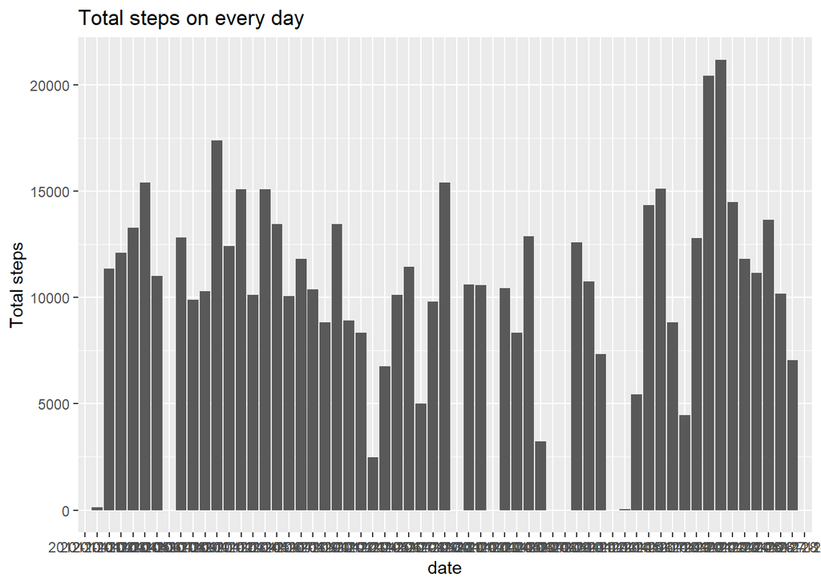

```r
g+geom_bar(stat="identity")+xlab("date")+ylab("Total steps")+ggtitle("Total steps on every day")
```

```r
png(file="plot1.1.png")
hist(q2$sum,xlab="Total steps",ylab="Count",main="Total steps histogram",breaks=25)
dev.off()
```

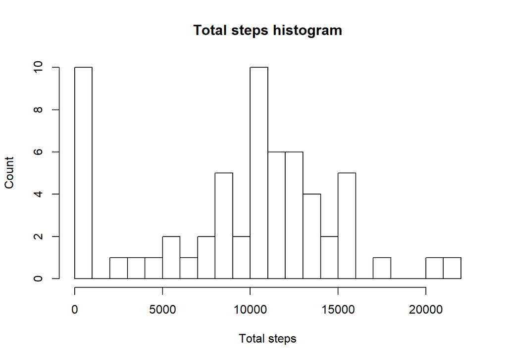

```r
hist(q2$sum,xlab="Total steps",ylab="Count",main="Total steps histogram",breaks=25)
```

3. Mean and Median of the total number of steps taken per day:

```r
q3<-data.frame(mean.steps=tapply(data$steps,data$date,mean))
q3$date<-rownames(q3)
rownames(q3)<-NULL
q3$median<-with(data,tapply(data$steps,data$date,median))
q3
```

```
##    mean.steps       date median
## 1          NA 2012-10-01     NA
## 2   0.4375000 2012-10-02      0
## 3  39.4166667 2012-10-03      0
## 4  42.0694444 2012-10-04      0
## 5  46.1597222 2012-10-05      0
## 6  53.5416667 2012-10-06      0
## 7  38.2465278 2012-10-07      0
## 8          NA 2012-10-08     NA
## 9  44.4826389 2012-10-09      0
## 10 34.3750000 2012-10-10      0
## 11 35.7777778 2012-10-11      0
## 12 60.3541667 2012-10-12      0
## 13 43.1458333 2012-10-13      0
## 14 52.4236111 2012-10-14      0
```

[output cut: 47 more lines]

**What is the average daily activity pattern?**

1. Time series plot of the average number of steps taken:

```r
q4<-data.frame(mean.steps=tapply(data$steps,data$date,mean,na.rm=TRUE))
q4$date<-rownames(q4)
library(lubridate)
```

```r
q4$date<-ymd(q4$date)
rownames(q4)<-NULL
library(ggplot2)
g<-ggplot(q4,aes(x=date,y=mean.steps))
png(file="plot2.png")
g+geom_bar(stat="identity")+xlab("Date")+ylab("average steps")+ggtitle("Time series plot")
dev.off()
```

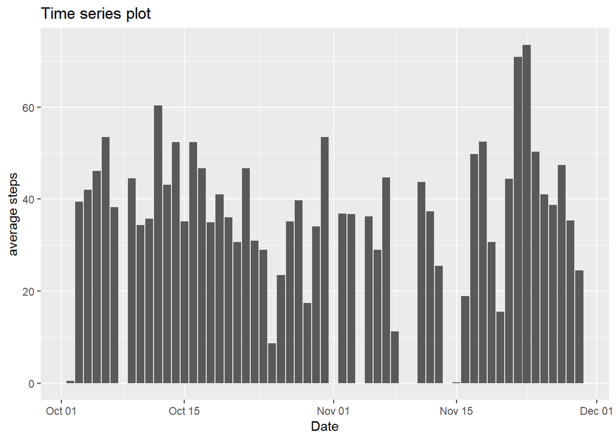

```r
g+geom_bar(stat="identity")+xlab("Date")+ylab("average steps")+ggtitle("Time series plot")
```

```r
q5<-data.frame(mean=tapply(data$steps,data$interval,mean,na.rm=TRUE))
q5$interval<-rownames(q5)
rownames(q5)<-NULL
q5[max(q5$mean),2]
```

```
## [1] "1705"
```

**Imputing missing values**

1. Total number of missing values:

```r
sum(is.na(data$steps))
```

```
## [1] 2304
```

2. Strategy for filling in all of the missing values in the dataset and creating a new dataset:

```r
newdata<-data
newdata$steps[is.na(newdata$steps)]<-mean(newdata$steps,na.rm=TRUE)
```

3. Histogram of the total number of steps taken each day for new data:

```r
newsub<-data.frame(sum=tapply(newdata$steps,newdata$date,sum))
newsub$date<-rownames(newsub)
rownames(newsub)<-NULL
png(file="plot10.png")
hist(newsub$sum,xlab="Total steps",ylab="count",main="Total number of steps",breaks=25)
dev.off()
```

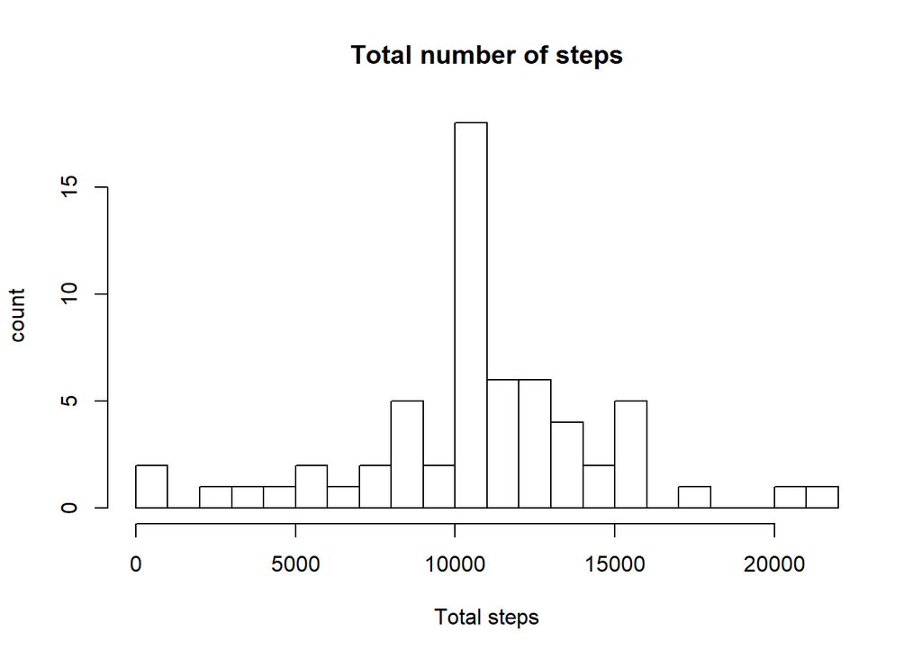

```r
hist(newsub$sum,xlab="Total steps",ylab="count",main="Total number of steps",breaks=25)
```

4. Mean and Median of total number of steps taken per day

```r
q6<-data.frame(mean.steps=tapply(newdata$steps,newdata$date,mean))
q6$date<-rownames(q6)
rownames(q6)<-NULL
q6$median<-with(newdata,tapply(newdata$steps,newdata$date,median))
q6
```

```
##    mean.steps       date  median
## 1  37.3825996 2012-10-01 37.3826
## 2   0.4375000 2012-10-02  0.0000
## 3  39.4166667 2012-10-03  0.0000
## 4  42.0694444 2012-10-04  0.0000
## 5  46.1597222 2012-10-05  0.0000
## 6  53.5416667 2012-10-06  0.0000
## 7  38.2465278 2012-10-07  0.0000
## 8  37.3825996 2012-10-08 37.3826
## 9  44.4826389 2012-10-09  0.0000
## 10 34.3750000 2012-10-10  0.0000
## 11 35.7777778 2012-10-11  0.0000
## 12 60.3541667 2012-10-12  0.0000
## 13 43.1458333 2012-10-13  0.0000
## 14 52.4236111 2012-10-14  0.0000
```

[output cut: 47 more lines]

*The mean and median differ in the both the date.*

**Are there differences in activity patterns between weekdays and weekends?**

1. Factor variable in the dataset with two levels – “weekday” and “weekend”:

```r
  library(lubridate)
  day<-weekdays(ymd(newdata$date))
  logic<-day %in%  c("Friday","Monday","Thursday","Tuesday","Wednesday")
  day[logic]<-"weekdays"
  day[!logic]<-"weekends"
  newdata$days<-day
```

2. Average number of steps taken graph:

```r
    sub1<-newdata[newdata$days=="weekdays",]
    sub2<-newdata[newdata$days=="weekends",]
    sub11<-data.frame(mean=tapply(sub1$steps,sub1$interval,mean))
    sub11$interval<-rownames(sub11)
    rownames(sub11)<-NULL
    sub22<-data.frame(mean=tapply(sub2$steps,sub2$interval,mean))
    sub22$interval<-rownames(sub22)
    rownames(sub22)<-NULL
    sub11<-sub11[c("interval","mean")]
    sub22<-sub22[c("interval","mean")]
    png(file="plot20.png")
    plot(sub11,type="l",col="red",xlab="interval",ylab="avg steps",main="Average steps wrt to interval")
    lines(sub22,col="blue")
    legend("topleft",col=c("red","blue"),legend=c("weekdays","weekends"),lty=1:1,title="line type")
    dev.off()
```

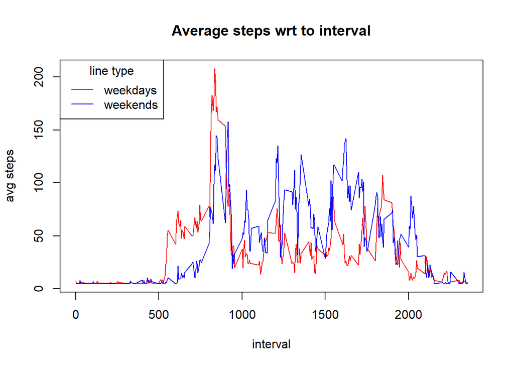

```r
    plot(sub11,type="l",col="red",xlab="interval",ylab="avg steps",main="Average steps wrt to interval")
    lines(sub22,col="blue")
    legend("topleft",col=c("red","blue"),legend=c("weekdays","weekends"),lty=1:1,title="line type")
```

3. Panel plot:

```r
    png(file="plot30.png")
    par(mfrow=c(2,1))
    plot(sub11,type="l",xlab="interval",ylab="avg steps",main="weekdays")
    plot(sub22,type="l",xlab="interval",ylab="avg steps",main="weekends")
    dev.off()
```

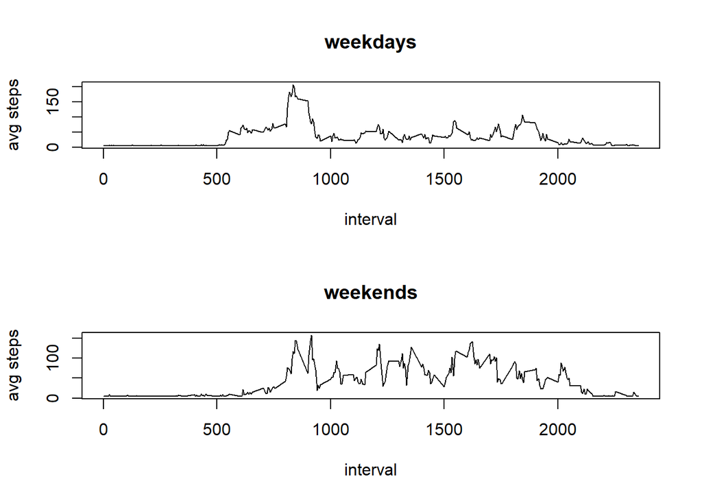

```r
    par(mfrow=c(2,1))
    plot(sub11,type="l",xlab="interval",ylab="avg steps",main="weekdays")
    plot(sub22,type="l",xlab="interval",ylab="avg steps",main="weekends")
```